[output not shown]

# —

- In each of the visualizations that we have made so far, there is some element of uncertainty around the quantity that we use to visualize it.

# Probabilities and frequencies

- Probability, and thus uncertainty, can be made a bit more concrete when we nest a particular outcome as a frequency or proportion.
- We have already done this some with bar charts or histograms. But, we can visualize this as an array.
- If we visualize an anticipated outcome and its probability relative to the other possible outcomes, this is called a **discrete outcome visualization**.
- To visualize probability as a likely frequency (e.g. 1 out of 100, 3 out of 40, etc.) is called frequency framing.

# An example from current polling data:

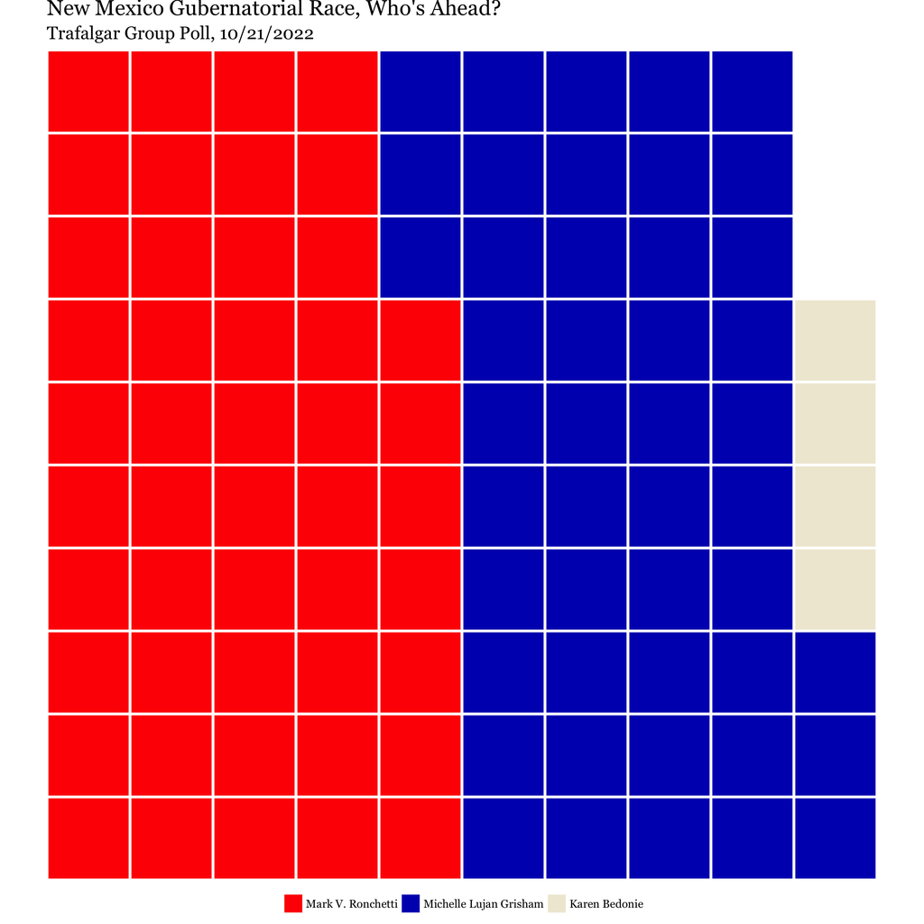

# Alternatively:

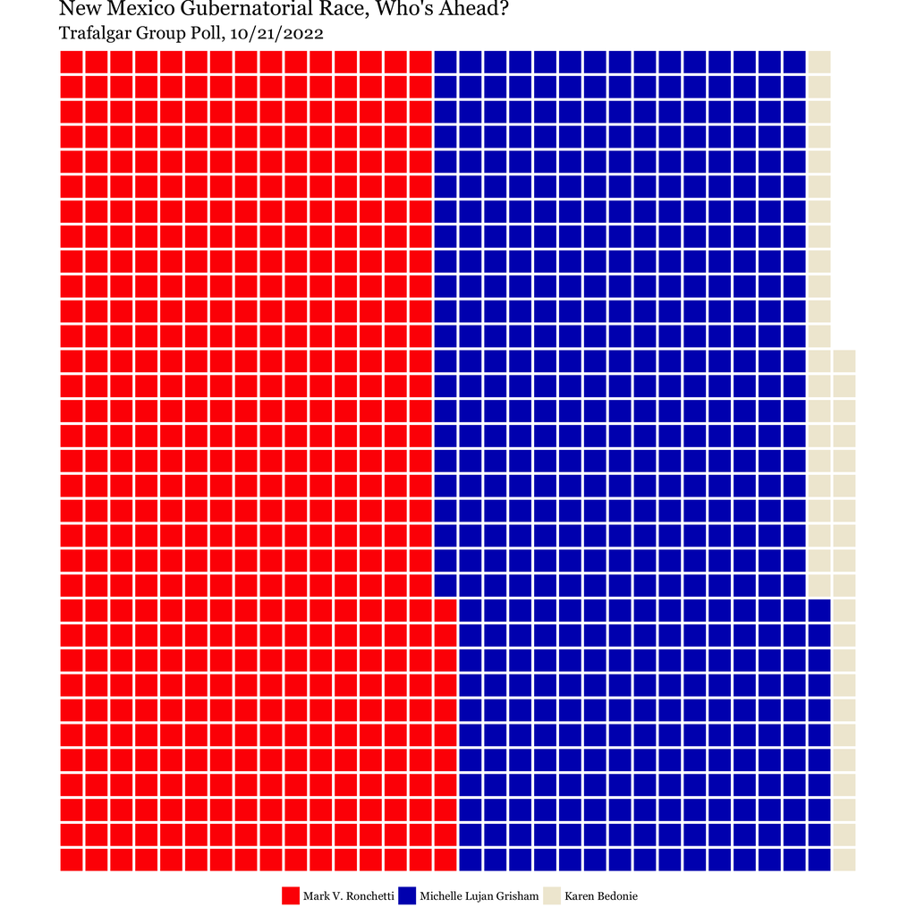

# And a different iteration, by pollster:

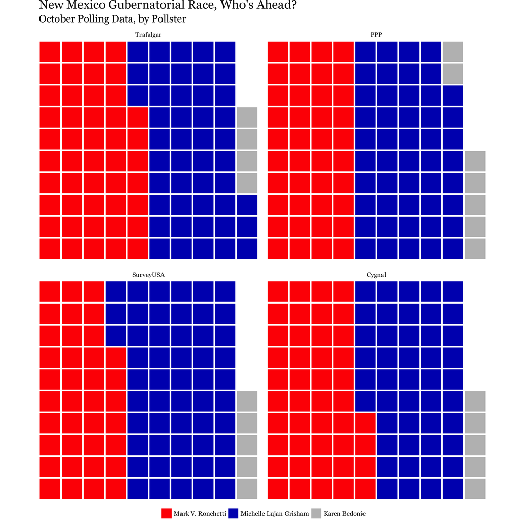

# Representing uncertainty via discrete outcomes

- This usually works pretty good as long as we are scaling appropriately. Can trade precision for interpretability’s sake, but NOT MUCH!
- People do better at perceiving these types of visualizations so long as the number is not *too* great.
- Possible to combine discrete outcome plots with a continuous distribution, but limited utility for our data potentially? (Quantile dotplot for those of you that are interested.) Can also be easily taken as plotting a continuum, rather than discrete event possibilities, therefore limiting their ease of interpretation.

# Key Change: Data Management

What are best data management practices YOU ALL know of?

I can wait…

# Data versions, saving data, sharing data, etc.

Let’s rank order these data file names from BEST to WORST:

1. `2018 Survey from Afrobarometer.csv(download)`
2. `2021_july21_media_survey_PANEL.csv`
3. `22-08-31_ColombiaStateCapacity_Project2020v2.dta`
4. `ANES_2018_v3.dta`
5. `2022-subset: anes.csv`

# What about code?

- *Annotated code is the best code!*
- Everything else is not great :)
- If I got locked out of this file for a year, what kind of signs would I want to have left myself so I can continue on without problem?
- Metaphor of parking on a downhill slope. I recommend the same for writing.